# Factorial Designs

Two-way anova with interactions

Dr. Samuel B Fernandes

2026-01-01

## Learning Objectives

By the end of this lectures (we will probably spend two lectures on this), you should be able to:

- Explain the advantage of factorial designs over one-factor-at-a-time experiments
- Construct the statistical model for a two-factor factorial: $y_{ijk} = \mu + \alpha_i + \beta_j + (\alpha\beta)_{ij} + \varepsilon_{ijk}$
- Design a factorial experiment using CRD or RCBD structure
- Create and interpret interaction plots to visualize how factors combine
- Conduct simple effects analysis when significant interactions are present
- Make appropriate statistical conclusions when interactions are significant vs non-significant

## Packages Used

```r
library(dplyr) # Data wrangling across examples
library(tidyr) # Reshaping data (herbicide example)
library(ggplot2) # Plots throughout
library(gridExtra) # Side-by-side layout comparison
library(FielDHub) # Factorial CRD/RCBD design generation
library(agricolae) # Herbicide RCBD design
library(car) # Type III ANOVA tables
library(emmeans) # Estimated marginal means and comparisons
library(parameters) # Model summaries (herbicide ANOVA)
library(performance) # Model diagnostics
library(multcomp) # Compact letter display
```

## Motivating Question

**Research scenario:**

You want to study the effects of **irrigation** and **nitrogen fertilizer** on corn yield.

**Two approaches:**

1. Run **two separate experiments** (one-factor-at-a-time)
2. Run **one factorial experiment** (both factors together)

Which approach is better? 🤔

## Review: Single-Factor Designs

**CRD (Completely Randomized Design):**

- One factor (treatment) with multiple levels
- Randomize treatments to experimental units
- ANOVA: Test treatment effect

**Example:** Nitrogen (0, 50, 100 kg/ha) on wheat yield

**RCBD (Randomized Complete Block Design):**

- One factor + blocking for spatial/temporal variation
- Complete set of treatments in each block
- ANOVA: Test treatment effect (accounting for blocks)

**Example:** Same nitrogen study, blocked by field location

**Limitation:** Both designs test **one factor at a time**. What if you want to test irrigation AND nitrogen simultaneously?

# Why Factorial Designs?

## One-Factor-At-a-Time (OFAT) Approach

**Experiment 1: Test Irrigation**

- Low irrigation (L) vs High irrigation (H)
- Keep nitrogen constant at 50 kg/ha
- 2 treatments × 8 reps = **16 plots**

**Result:** High irrigation increases yield by 500 kg/ha

**Experiment 2: Test Nitrogen**

- No nitrogen (0) vs High nitrogen (100 kg/ha)
- Keep irrigation constant at Low
- 2 treatments × 8 reps = **16 plots**

**Result:** Nitrogen increases yield by 300 kg/ha

**Problem with OFAT:**

- **Total plots:** 32
- **Conclusion:** “Add high irrigation (+500 kg/ha) and nitrogen (+300 kg/ha) for +800 kg/ha total”
- **Hidden assumption:** Effects are **independent** (additive)
- **Risk:** What if nitrogen only works with high irrigation? **You’ll never know!**

## Factorial Solution: Test All Combinations

**2×2 Factorial Design:**

- Factor A: **Irrigation** (Low, High)
- Factor B: **Nitrogen** (0, 100 kg/ha)
- **Replication:** 8 reps per combination
- **Total plots:** 4 × 8 = **32 plots** (same as OFAT!)

**Treatment combinations:** 4 (all possible pairs)

1. Low Irrigation + No Nitrogen (L0)
2. Low Irrigation + High Nitrogen (L100)
3. High Irrigation + No Nitrogen (H0)
4. High Irrigation + High Nitrogen (H100)

**Treatment Structure Table:**

| Irrigation | N = 0 | N = 100 |
| --- | --- | --- |
| **Low** | L0 | L100 |
| **High** | H0 | H100 |

**Factorial advantage:**

- Same sample size (32 plots)
- **More information:** Tests irrigation effect, nitrogen effect, AND their interaction!

## Factorial Notation

**Factorial designs are described by the number of factors and their levels:**

- **2×2 factorial:** 2 factors, each with 2 levels → 4 treatment combinations
- **3×3 factorial:** 2 factors, each with 3 levels → 9 treatment combinations
- **2×4 factorial:** 2 factors (2 levels, 4 levels) → 8 treatment combinations
- **2×2×2 factorial:** 3 factors, each with 2 levels → 8 treatment combinations
- **2^k factorial:** k factors, all with 2 levels → $2^k$ combinations

**Examples:**

| Design | Factors | Levels | Combinations |
| --- | --- | --- | --- |
| 2×2 | Irrigation (2) × Nitrogen (2) | 2, 2 | 4 |
| 3×3 | Irrigation (3) × Nitrogen (3) | 3, 3 | 9 |
| 2×3 | Tillage (2) × Variety (3) | 2, 3 | 6 |
| 2×2×2 | Tillage × Variety × Fungicide | 2, 2, 2 | 8 |

# Main Effects and Interactions

## What is a Main Effect?

**Main effect of Factor A:**

The **average effect** of Factor A **across all levels of Factor B**.

- Compares marginal means (averaged over other factors)
- Ignores specific combinations
- Answers: “On average, does Factor A matter?”

**Example: Main effect of Irrigation**

**Mean yield under Low Irrigation:**
$$\bar{y}_{\text{Low}} = \frac{y_{L0} + y_{L100}}{2}$$

Average of L0 and L100 (across both nitrogen levels)

**Mean yield under High Irrigation:**
$$\bar{y}_{\text{High}} = \frac{y_{H0} + y_{H100}}{2}$$

Average of H0 and H100

**Main effect of Irrigation:**
$$\text{Main Effect}_{\text{Irrigation}} = \bar{y}_{\text{High}} - \bar{y}_{\text{Low}}$$

## What is an Interaction?

**Interaction between Factor A and Factor B:**

The effect of Factor A **depends on** the level of Factor B (or vice versa).

- Main effects are **not additive**
- Simple effects (A at each level of B) differ
- Answers: “Do factors work together in a non-additive way?”

**Example: Irrigation × Nitrogen Interaction**

**If no interaction:**

- Nitrogen effect at Low Irrigation = +200 kg/ha
- Nitrogen effect at High Irrigation = +200 kg/ha
- “Nitrogen increases yield by 200 kg/ha regardless of irrigation level”

**If interaction present:**

- Nitrogen effect at Low Irrigation = +200 kg/ha
- Nitrogen effect at High Irrigation = +1000 kg/ha
- “Nitrogen benefit is much larger under high irrigation!”
- **Factors interact** (synergy)

**Biological interpretation:**

Nitrogen uptake requires adequate water. Under drought (low irrigation), plants can’t utilize added nitrogen. Under high irrigation, nitrogen is fully effective → **synergistic interaction**.

## Interaction Plot

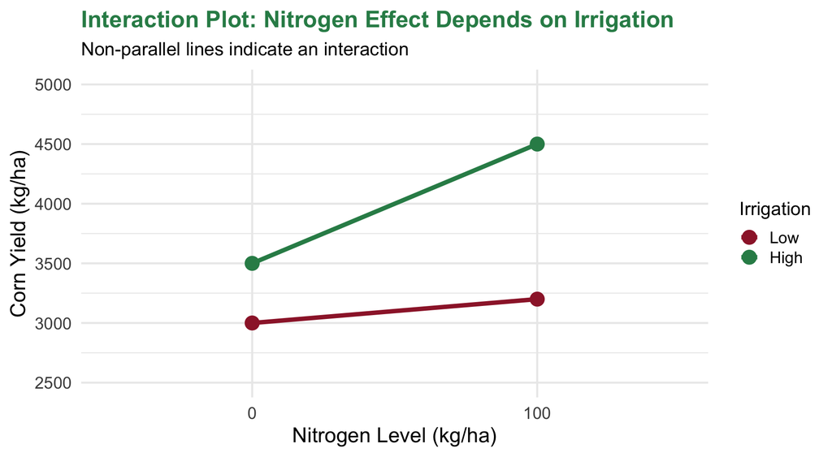

Figure 1: Conceptual interaction plot: Nitrogen effect depends on irrigation

**Key observation:** Lines are **not parallel** → Interaction present!

- Under **low irrigation** (red): Nitrogen increases yield slightly (3000 → 3200)
- Under **high irrigation** (green): Nitrogen increases yield substantially (3500 → 4500)
- **Interpretation:** Nitrogen benefit depends on irrigation level

# Statistical Model for Factorial Designs

## Two-Factor Factorial Model

**Mathematical model for 2×2 factorial:**

$$y_{ijk} = \mu + \alpha_i + \beta_j + (\alpha\beta)_{ij} + \varepsilon_{ijk}$$

**Where:**

- $y_{ijk}$ = response (e.g., yield) for observation $k$ in treatment $i, j$
- $\mu$ = overall mean (grand mean)
- $\alpha_i$ = main effect of Factor A (e.g., irrigation), $i = 1, 2$
- $\beta_j$ = main effect of Factor B (e.g., nitrogen), $j = 1, 2$
- $(\alpha\beta)_{ij}$ = interaction effect between Factors A and B
- $\varepsilon_{ijk}$ = random error, $\varepsilon_{ijk} \sim N(0, \sigma^2)$

## Assumptions

**Same assumptions as CRD and RCBD:**

1. **Independence:** Observations are independent (proper randomization)
2. **Normality:** Errors $\varepsilon_{ijk}$ are normally distributed
3. **Homogeneity of variance:** Equal variance across all treatment combinations ($\sigma^2$ constant)
4. **Additivity:** Model is additive (or check for interaction if suspected)

**Checking assumptions:**

- **Residual plots** (normality, constant variance, outliers)
- **Shapiro-Wilk test** (normality)
- **Levene’s test** (homogeneity of variance)

## ANOVA for Factorial Design

**ANOVA partitions total variation into:**

$$\text{SS}_{\text{Total}} = \text{SS}_A + \text{SS}_B + \text{SS}_{A \times B} + \text{SS}_{\text{Error}}$$

**Sources of variation:**

1. **Main effect of Factor A** (irrigation)
2. **Main effect of Factor B** (nitrogen)
3. **Interaction A×B** (irrigation × nitrogen)
4. **Error** (within-treatment variation)

**ANOVA Table Structure:**

| Source | df | SS | MS | F | p-value |
| --- | --- | --- | --- | --- | --- |
| Factor A | $a-1$ | $SS_A$ | $MS_A$ | $\frac{MS_A}{MS_E}$ |  |
| Factor B | $b-1$ | $SS_B$ | $MS_B$ | $\frac{MS_B}{MS_E}$ |  |
| A×B | $(a-1)(b-1)$ | $SS_{A \times B}$ | $MS_{A \times B}$ | $\frac{MS_{A \times B}}{MS_E}$ |  |
| Error | $ab(r-1)$ | $SS_E$ | $MS_E$ |  |  |
| **Total** | $abr - 1$ | $SS_{\text{Total}}$ |  |  |  |

## Hypotheses Tested

**Main effect of Factor A (Irrigation):**

$$H_0: \alpha_1 = \alpha_2 = 0$$
$$H_A: \text{At least one } \alpha_i \neq 0$$

“Is there an average difference between irrigation levels?”

**Main effect of Factor B (Nitrogen):**

$$H_0: \beta_1 = \beta_2 = 0$$
$$H_A: \text{At least one } \beta_j \neq 0$$

“Is there an average difference between nitrogen levels?”

**Interaction A×B (Irrigation × Nitrogen):**

$$H_0: (\alpha\beta)_{ij} = 0 \text{ for all } i, j$$
$$H_A: \text{At least one } (\alpha\beta)_{ij} \neq 0$$

“Does the effect of nitrogen depend on irrigation level (or vice versa)?”

# Designing a Factorial Experiment

## Factorial + CRD Structure

**Factorial CRD:**

- Treatment structure: Factorial (e.g., 2×2 = 4 combinations)
- Design structure: Completely randomized (no blocks)
- Randomize all treatment combinations to experimental units

**When to use:**

- Homogeneous experimental environment
- No obvious blocking factor

**Example R code with FielDHub:**

```r
# Generate 2×2 factorial CRD
design_factorial_crd <- FielDHub::CRD(
    t = 4, # 4 treatment combinations (2×2)
    reps = 8, # 8 replicates
    plotNumber = 101,
    seed = 2026,
    locationName = "Research Farm"
)

# View layout
print(design_factorial_crd)
plot(design_factorial_crd)
```

## Factorial + RCBD Structure

**Factorial RCBD:**

- Treatment structure: Factorial (e.g., 2×2 = 4 combinations)
- Design structure: Randomized complete block
- Each block contains all 4 treatment combinations (complete)

**When to use:**

- Heterogeneous environment (field gradient, time variability)
- Want to control for blocking factor

**Example R code with FielDHub:**

```r
# Generate 2×2 factorial RCBD
design_factorial_rcbd <- FielDHub::RCBD(
    t = 4, # 4 treatment combinations (2×2)
    reps = 8, # 8 blocks
    plotNumber = 101,
    seed = 2026,
    locationName = "Field Trial"
)

# View layout
print(design_factorial_rcbd)
plot(design_factorial_rcbd)
```

## Design Considerations

**Key design decisions for factorials:**

1. **How many factors?**
   - Start with 2-3 factors (more factors = exponential growth in plots)
   - Example: 2×2×2 = 8 combinations; 3×3×3 = 27 combinations
2. **How many levels per factor?**
   - 2 levels: Compare two conditions (yes/no, low/high)
   - 3+ levels: Dose-response, multiple varieties
3. **Replication:**
   - Need sufficient power: 6-10 reps per combination typical
   - Power analysis: Estimate from pilot data or literature
4. **Design structure:**
   - CRD if environment homogeneous
   - RCBD if spatial/temporal variation expected

# What is an Interaction?

## Interaction: Definition

**Interaction between Factor A and Factor B:**

The effect of Factor A **depends on** the level of Factor B (or equivalently, the effect of Factor B depends on the level of Factor A).

**Synonyms:**

- Non-additive effect
- Synergistic/antagonistic effect
- Conditional effect
- Moderation

**Key insight:** When an interaction is present, you **cannot interpret main effects in isolation**—you must consider factor combinations.

## No Interaction vs Interaction

**Scenario 1: No Interaction (Additive)**

| Irrigation | N=0 | N=100 | **N effect** |
| --- | --- | --- | --- |
| **Low** | 3000 | 3400 | **+400** |
| **High** | 3500 | 3900 | **+400** |
| **Irrig effect** | +500 | +500 |  |

✓ Nitrogen effect is **the same** (+400) at both irrigation levels

✓ Irrigation effect is **the same** (+500) at both nitrogen levels

✓ Effects are **additive**

**Scenario 2: Interaction Present**

| Irrigation | N=0 | N=100 | **N effect** |
| --- | --- | --- | --- |
| **Low** | 3000 | 3200 | **+200** |
| **High** | 3500 | 4500 | **+1000** |
| **Irrig effect** | +500 | +1300 |  |

**Caution**

✗ Nitrogen effect **differs** (+200 vs +1000)

✗ Irrigation effect **differs** (+500 vs +1300)

✗ Effects are **non-additive** → **Interaction!**

## Visual Check: Interaction Plots

**Interaction plot:**

- X-axis: One factor (e.g., Nitrogen)
- Y-axis: Response (e.g., Yield)
- Lines: Levels of the other factor (e.g., Irrigation)

**Interpretation rule:**

- **Parallel lines** → No interaction (additive effects)
- **Non-parallel lines** → Interaction present (non-additive effects)

## Interaction Plot: No Interaction

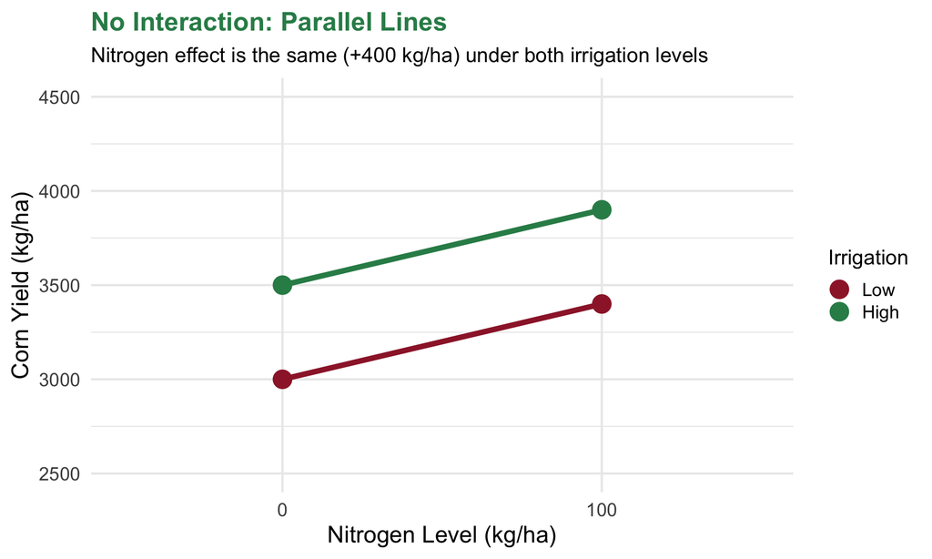

Figure 2: No interaction: Parallel lines indicate additive effects

```r
library(ggplot2)
library(dplyr)

# Data: No interaction (additive)
no_interaction <- data.frame(
  Irrigation = rep(c("Low", "High"), each = 2),
  Nitrogen = rep(c("0", "100"), times = 2),
  Yield = c(3000, 3400, 3500, 3900)  # N adds 400 everywhere
)

no_interaction$Irrigation <- factor(no_interaction$Irrigation, levels = c("Low", "High"))
no_interaction$Nitrogen <- factor(no_interaction$Nitrogen, levels = c("0", "100"))

# Interaction plot
ggplot(no_interaction, aes(x = Nitrogen, y = Yield,
                           color = Irrigation, group = Irrigation)) +
  geom_line(linewidth = 2) +
  geom_point(size = 6) +
  labs(
    title = "No Interaction: Parallel Lines",
    subtitle = "Nitrogen effect is the same (+400 kg/ha) under both irrigation levels",
    x = "Nitrogen Level (kg/ha)",
    y = "Corn Yield (kg/ha)",
    color = "Irrigation"
  ) +
  scale_color_manual(values = c("Low" = "#9D2235", "High" = "#2E8B57")) +
  scale_y_continuous(limits = c(2500, 4500), breaks = seq(2500, 4500, 500)) +
  theme_minimal(base_size = 18) +
  theme(
    plot.title = element_text(color = "#2E8B57", face = "bold", size = 20),
    plot.subtitle = element_text(size = 16),
    legend.position = "right",
    legend.title = element_text(size = 16),
    legend.text = element_text(size = 14)
  )
```

**Parallel lines:** Slope is identical for both irrigation levels → **No interaction**. You can interpret main effects directly.

## Interaction Plot: Synergistic Interaction

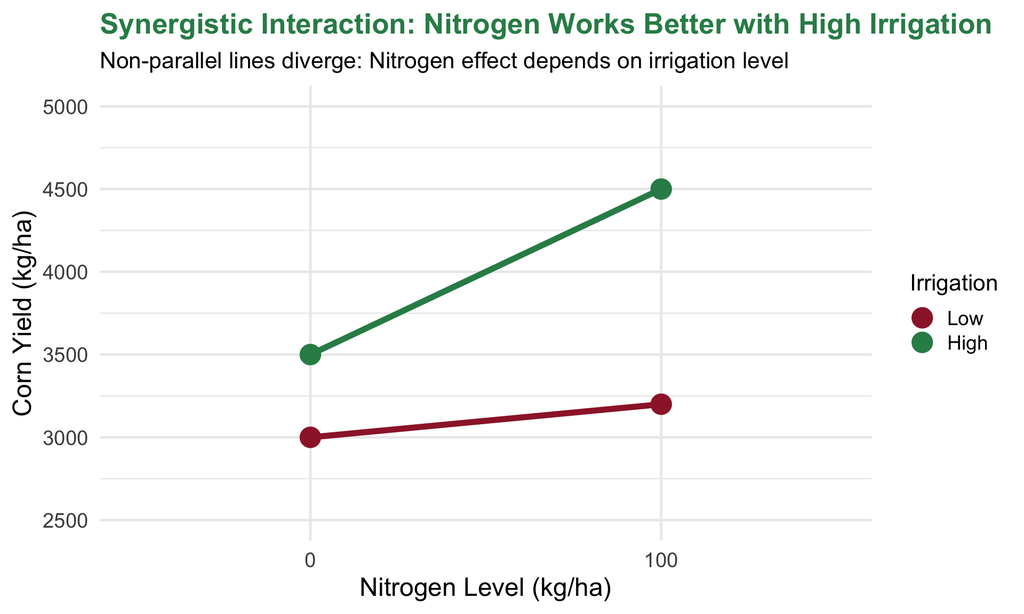

Figure 3: Synergistic interaction: Nitrogen effect amplified under high irrigation

```r
# Data: Synergistic interaction
synergistic <- data.frame(
  Irrigation = rep(c("Low", "High"), each = 2),
  Nitrogen = rep(c("0", "100"), times = 2),
  Yield = c(3000, 3200, 3500, 4500)  # N effect larger under high irrigation
)

synergistic$Irrigation <- factor(synergistic$Irrigation, levels = c("Low", "High"))
synergistic$Nitrogen <- factor(synergistic$Nitrogen, levels = c("0", "100"))

# Interaction plot
ggplot(synergistic, aes(x = Nitrogen, y = Yield,
                        color = Irrigation, group = Irrigation)) +
  geom_line(linewidth = 2) +
  geom_point(size = 6) +
  labs(
    title = "Synergistic Interaction: Nitrogen Works Better with High Irrigation",
    subtitle = "Non-parallel lines diverge: Nitrogen effect depends on irrigation level",
    x = "Nitrogen Level (kg/ha)",
    y = "Corn Yield (kg/ha)",
    color = "Irrigation"
  ) +
  scale_color_manual(values = c("Low" = "#9D2235", "High" = "#2E8B57")) +
  scale_y_continuous(limits = c(2500, 5000), breaks = seq(2500, 5000, 500)) +
  theme_minimal(base_size = 18) +
  theme(
    plot.title = element_text(color = "#2E8B57", face = "bold", size = 20),
    plot.subtitle = element_text(size = 16),
    legend.position = "right",
    legend.title = element_text(size = 16),
    legend.text = element_text(size = 14)
  )
```

**Non-parallel lines (diverging):** Green line (high irrigation) has steeper slope than red line (low irrigation) → **Synergistic interaction**. Factors amplify each other’s effects.

# Types of Interactions

## Synergistic Interaction

**Synergistic interaction:**

The combined effect of two factors is **greater than** the sum of their individual effects.

**Visual cue:** Non-parallel lines that **diverge** (spread apart)

**Example:** Fungicide + resistant variety control disease better together than expected from their individual effects

**Why it happens:**

- Factors **amplify** each other’s effects
- Common in biology: Nutrients need water, herbicides need adjuvants, genes interact epistatically

**Practical implication:**

- “Use both factors together for maximum benefit”
- Combined treatment is most cost-effective

## Antagonistic Interaction

**Antagonistic interaction:**

The combined effect of two factors is **less than** the sum of their individual effects.

**Visual cue:** Non-parallel lines that **converge** (come together)

**Example:** High temperature reduces fertilizer benefit (heat stress limits nutrient uptake)

**Why it happens:**

- One factor **dampens** or **limits** the effect of the other
- Stress conditions, resource competition, physiological constraints

**Practical implication:**

- “One factor might not be worth adding if the other is unfavorable”
- Optimize one factor before investing in the other

## Crossover Interaction

**Crossover interaction:**

The ranking of one factor’s levels **reverses** depending on the level of the other factor.

**Visual cue:** Lines **cross** each other

**Example:** Variety A best in Location 1, but Variety B best in Location 2 (genotype × environment interaction)

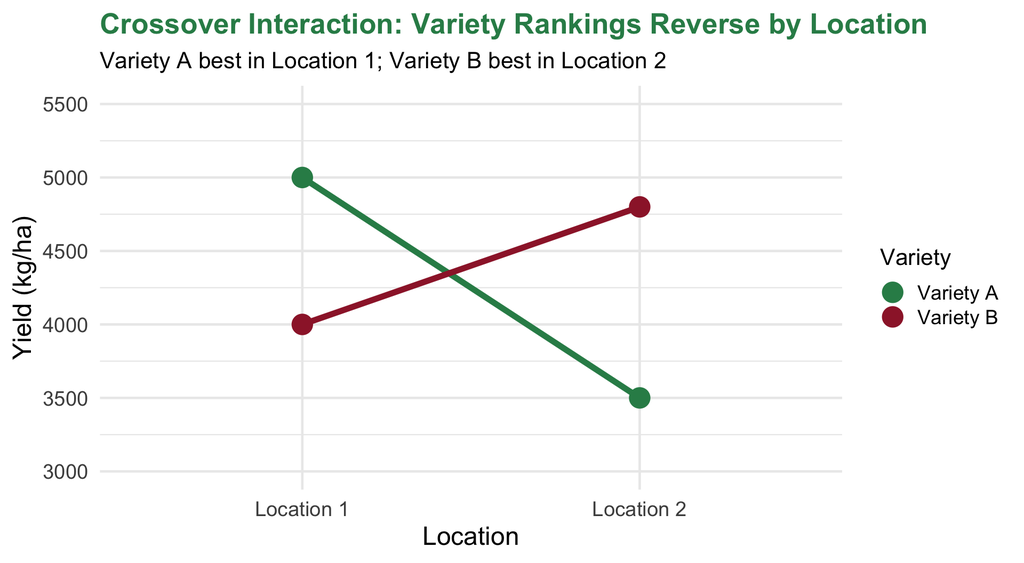

Figure 4: Crossover interaction: Rankings reverse across locations

## Summary: Types of Interactions

| **Type** | **Visual Cue** | **Effect** | **Example** |
| --- | --- | --- | --- |
| **Synergistic** | Lines diverge | Combined effect > sum | Fertilizer + irrigation amplify each other |
| **Antagonistic** | Lines converge | Combined effect < sum | Heat stress reduces fertilizer benefit |
| **Crossover** | Lines cross | Rankings reverse | Variety A best in Loc 1; Variety B best in Loc 2 |
| **No interaction** | Lines parallel | Effects additive | Nitrogen adds same amount everywhere |

**Key message:** The type of interaction dictates your management recommendations. Always visualize interactions with plots!

# ANOVA for Factorial Designs

## ANOVA Table for 2×2 Factorial

**Factorial ANOVA tests THREE hypotheses:**

1. **Main effect of Factor A** (e.g., Irrigation)
2. **Main effect of Factor B** (e.g., Nitrogen)
3. **Interaction A×B** (Irrigation × Nitrogen)

**Critical rule:** Test the **interaction first**! Interpretation depends on whether interaction is significant.

**ANOVA table structure:**

| Source | df | SS | MS | F | p-value |
| --- | --- | --- | --- | --- | --- |
| **Irrigation (A)** | $a-1 = 1$ | $SS_A$ | $MS_A$ | $F_A$ | $p_A$ |
| **Nitrogen (B)** | $b-1 = 1$ | $SS_B$ | $MS_B$ | $F_B$ | $p_B$ |
| **A×B Interaction** | $(a-1)(b-1) = 1$ | $SS_{AB}$ | $MS_{AB}$ | $F_{AB}$ | $p_{AB}$ |
| **Error** | $ab(r-1) = 28$ | $SS_E$ | $MS_E$ | — | — |
| **Total** | $abr-1 = 31$ | $SS_{\text{Total}}$ | — | — | — |

## Interpretation Decision Tree

**Step 1: Test interaction**

- If **p(A×B) < 0.05** → **Interaction is significant**
  - **Action:** Conduct **simple effects analysis** (test Factor A at each level of Factor B separately)
  - **Do NOT interpret main effects alone**—they’re misleading!
- If **p(A×B) ≥ 0.05** → **Interaction is not significant**
  - **Action:** Interpret **main effects** (Factor A and Factor B)
  - Factors work independently (additive)

**Common mistake:**

“My interaction is significant (p < 0.05), but I’ll still report main effects.”

**Wrong!** If interaction is significant, main effects don’t tell the full story. You must analyze simple effects.

# Simple Effects Analysis

## What Are Simple Effects?

**Simple effect:**

The effect of **one factor at a specific level of another factor**.

**When to use:** When the interaction is significant (p < 0.05)

**Example:** - Simple effect of Nitrogen at **Low Irrigation** - Simple effect of Nitrogen at **High Irrigation**

Answers: “Does nitrogen matter under low irrigation? Does nitrogen matter under high irrigation?”

## R Code: Simple Effects with emmeans

```r
library(emmeans)
library(car)

# Assume you've fitted a model:
# model <- lm(Yield ~ Irrigation * Nitrogen, data = factorial_data)

# Step 1: Test interaction
Anova(model, type = "III")

# If interaction p < 0.05, proceed to simple effects:

# Step 2: Simple effects of Nitrogen at each Irrigation level
emm_simple <- emmeans(model, ~ Nitrogen | Irrigation)
summary(emm_simple)

# Step 3: Pairwise comparisons within each Irrigation level
pairs(emm_simple)

# Step 4: Visualize with interaction plot
emmip(model, Irrigation ~ Nitrogen, CIs = TRUE)
```

**emmeans syntax:**

- `~ Nitrogen | Irrigation` means “Test Nitrogen effect **at each level of Irrigation**”
- `pairs()` conducts pairwise comparisons (e.g., N=0 vs N=100) within each irrigation level
- `emmip()` creates an interaction plot with confidence intervals

## Example: Simple Effects Output

**Hypothetical emmeans output:**

```
Irrigation = Low:
 Nitrogen emmean    SE  df lower.CL upper.CL
 0          3000  50  28     2900     3100
 100        3200  50  28     3100     3300

Irrigation = High:
 Nitrogen emmean    SE  df lower.CL upper.CL
 0          3500  50  28     3400     3600
 100        4500  50  28     4400     4600
```

**Pairwise comparisons:**

```
Irrigation = Low:
 contrast   estimate   SE df t.ratio p.value
 0 - 100       -200   71 28  -2.82   0.009

Irrigation = High:
 contrast   estimate   SE df t.ratio p.value
 0 - 100      -1000   71 28 -14.08   <.0001
```

**Interpretation:**

- **Low irrigation:** Nitrogen increases yield by 200 kg/ha (p = 0.009, significant but modest)
- **High irrigation:** Nitrogen increases yield by 1000 kg/ha (p < 0.0001, highly significant)
- **Conclusion:** Nitrogen benefit is **5× larger** under high irrigation → Strong interaction!

# R Demo: Complete Factorial Analysis

## Example Dataset: Irrigation × Nitrogen

```r
library(dplyr)
library(ggplot2)
library(car)
library(emmeans)

# Simulate factorial data with interaction
set.seed(2026)
factorial_data <- expand.grid(
  Irrigation = factor(c("Low", "High"), levels = c("Low", "High")),
  Nitrogen = factor(c("0", "100"), levels = c("0", "100")),
  Rep = 1:8
) |>
  mutate(
    # True means with interaction
    mu = case_when(
      Irrigation == "Low" & Nitrogen == "0" ~ 3000,
      Irrigation == "Low" & Nitrogen == "100" ~ 3200,
      Irrigation == "High" & Nitrogen == "0" ~ 3500,
      Irrigation == "High" & Nitrogen == "100" ~ 4500
    ),
    Yield = mu + rnorm(n(), mean = 0, sd = 150)  # Add random error
  )

# Preview data
head(factorial_data, 10)
```

```
#>    Irrigation Nitrogen Rep   mu    Yield
#> 1         Low        0   1 3000 3078.088
#> 2        High        0   1 3500 3338.046
#> 3         Low      100   1 3200 3220.886
#> 4        High      100   1 4500 4487.288
#> 5         Low        0   2 3000 2900.004
#> 6        High        0   2 3500 3122.587
#> 7         Low      100   2 3200 3089.728
#> 8        High      100   2 4500 4346.982
#> 9         Low        0   3 3000 3017.033
#> 10       High        0   3 3500 3428.931
```

## Step 1: Interaction Plot

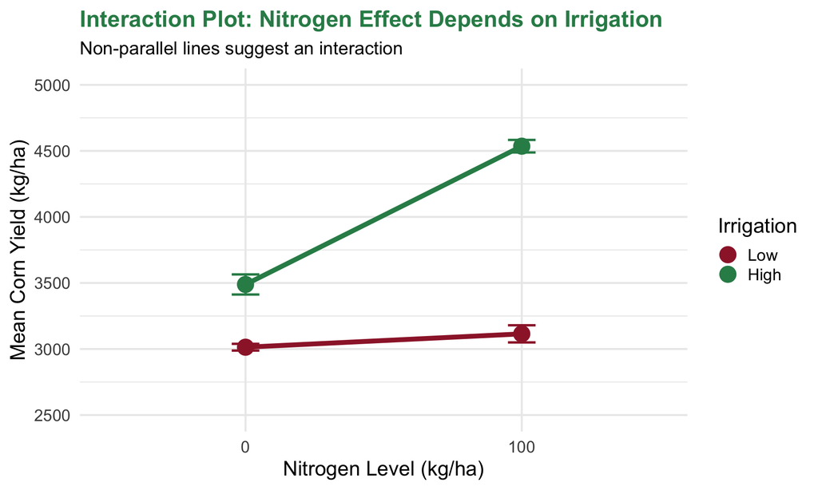

Figure 5: Interaction plot: Nitrogen × Irrigation on corn yield

```r
# Compute summary statistics
factorial_summary <- factorial_data |>
  group_by(Irrigation, Nitrogen) |>
  summarise(
    mean_yield = mean(Yield),
    se_yield = sd(Yield) / sqrt(n()),
    .groups = "drop"
  )

# Interaction plot
ggplot(factorial_summary, aes(x = Nitrogen, y = mean_yield,
                              color = Irrigation, group = Irrigation)) +
  geom_line(linewidth = 2) +
  geom_point(size = 6) +
  geom_errorbar(aes(ymin = mean_yield - se_yield, ymax = mean_yield + se_yield),
                width = 0.1, linewidth = 1) +
  labs(
    title = "Interaction Plot: Nitrogen Effect Depends on Irrigation",
    subtitle = "Non-parallel lines suggest an interaction",
    x = "Nitrogen Level (kg/ha)",
    y = "Mean Corn Yield (kg/ha)",
    color = "Irrigation"
  ) +
  scale_color_manual(values = c("Low" = "#9D2235", "High" = "#2E8B57")) +
  scale_y_continuous(limits = c(2500, 5000), breaks = seq(2500, 5000, 500)) +
  theme_minimal(base_size = 18) +
  theme(
    plot.title = element_text(color = "#2E8B57", face = "bold", size = 20),
    plot.subtitle = element_text(size = 16),
    legend.position = "right"
  )
```

Lines are **non-parallel** (diverging) → Suggests interaction. Let’s test it statistically!

## Step 2: Fit Model and ANOVA

```r
# Fit factorial model with interaction
model_factorial <- lm(Yield ~ Irrigation * Nitrogen, data = factorial_data)

# Type III ANOVA (tests main effects and interaction)
Anova(model_factorial, type = "III")
```

```
#> Anova Table (Type III tests)
#>
#> Response: Yield
#>                       Sum Sq Df   F value    Pr(>F)
#> (Intercept)         72656092  1 2813.9233 < 2.2e-16 ***
#> Irrigation            902301  1   34.9455 2.323e-06 ***
#> Nitrogen               40908  1    1.5844    0.2185
#> Irrigation:Nitrogen  1788913  1   69.2834 4.679e-09 ***
#> Residuals             722966 28
#> ---
#> Signif. codes:  0 '***' 0.001 '**' 0.01 '*' 0.05 '.' 0.1 ' ' 1
```

**Interpretation:** Since interaction is significant, we **must** conduct simple effects analysis. Main effects alone are insufficient.

## Step 3: Simple Effects Analysis

```r
# Estimated marginal means: Nitrogen at each Irrigation level
emm_simple <- emmeans(model_factorial, ~ Nitrogen | Irrigation)
summary(emm_simple)
```

```
#> Irrigation = Low:
#>  Nitrogen emmean   SE df lower.CL upper.CL
#>  0          3014 56.8 28     2897     3130
#>  100        3115 56.8 28     2998     3231
#>
#> Irrigation = High:
#>  Nitrogen emmean   SE df lower.CL upper.CL
#>  0          3489 56.8 28     3372     3605
#>  100        4535 56.8 28     4419     4652
#>
#> Confidence level used: 0.95
```

```r
# Pairwise comparisons (simple effects)
pairs(emm_simple)
```

```
#> Irrigation = Low:
#>  contrast                estimate   SE df t.ratio p.value
#>  Nitrogen0 - Nitrogen100     -101 80.3 28  -1.259  0.2185
#>
#> Irrigation = High:
#>  contrast                estimate   SE df t.ratio p.value
#>  Nitrogen0 - Nitrogen100    -1047 80.3 28 -13.030  <.0001
```

## Step 4: Visualize Simple Effects

```r
# Interaction plot with emmeans (includes CIs)
emmip(model_factorial, Irrigation ~ Nitrogen, CIs = TRUE,
      linewidth = 1.5, dotsize = 4) +
  labs(
    title = "Estimated Marginal Means: Nitrogen × Irrigation",
    subtitle = "Confidence intervals show precision of estimates",
    x = "Nitrogen Level (kg/ha)",
    y = "Estimated Mean Yield (kg/ha)",
    color = "Irrigation"
  ) +
  scale_color_manual(values = c("Low" = "#9D2235", "High" = "#2E8B57")) +
  theme_minimal(base_size = 18) +
  theme(
    plot.title = element_text(color = "#2E8B57", face = "bold", size = 20),
    plot.subtitle = element_text(size = 16),
    legend.position = "right"
  )
```

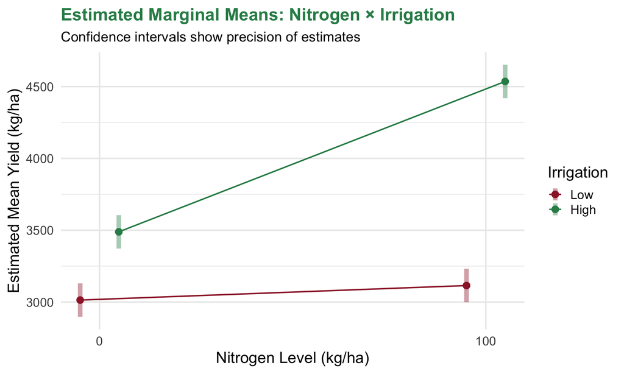

Figure 6: Simple effects: Nitrogen effect at each irrigation level

# Your Turn: Interpret an Interaction

## Activity (3 minutes)

**Scenario:**

You tested two tillage methods (Conventional, No-till) and two fungicide treatments (None, Applied) on soybean yield. Here are the means:

| Tillage | Fungicide=None | Fungicide=Applied | **Fungicide effect** |
| --- | --- | --- | --- |
| **Conventional** | 2800 kg/ha | 2850 kg/ha | **+50 kg/ha** |
| **No-till** | 2500 kg/ha | 3200 kg/ha | **+700 kg/ha** |

**Questions:** 1. Is there an interaction? How do you know? 2. What type of interaction (synergistic, antagonistic, crossover)? 3. What would you recommend to a farmer using no-till? Conventional tillage?

**Discuss with a partner, then we’ll share answers.**

## Activity: Solutions

**Answers:**

1. **Yes, interaction present**
   - Fungicide effect is +50 kg/ha under conventional tillage
   - Fungicide effect is +700 kg/ha under no-till
   - Effects differ → Interaction!
2. **Synergistic interaction**
   - Fungicide benefit is amplified under no-till
   - Lines would diverge on an interaction plot
3. **Recommendations:**

**For no-till farmers:** - Definitely apply fungicide (+700 kg/ha gain!) - Strong ROI due to higher disease pressure

**For conventional tillage farmers:** - Fungicide helps only slightly (+50 kg/ha) - May not justify cost (marginal benefit)

**Key lesson:** Management advice depends on tillage system due to interaction!

## Key Takeaways

1. **Factorial designs test multiple factors simultaneously** in one experiment
2. **OFAT (one-factor-at-a-time) is inefficient** and misses interactions
3. **Main effects** = average effect of a factor across all levels of other factors
4. **Interactions** = effect of one factor depends on the level of another factor
5. **Model:** $y_{ijk} = \mu + \alpha_i + \beta_j + (\alpha\beta)_{ij} + \varepsilon_{ijk}$
6. **ANOVA tests** main effects (A, B) and interaction (A×B) separately
7. **Design structure:** Use CRD or RCBD depending on experimental environment
8. **Efficiency advantage:** More information per experimental unit

## Factorial Advantages

**Why use factorial designs?**

✓ **Efficiency:** Test multiple factors in one experiment (saves time, resources)

✓ **Interaction detection:** OFAT misses interactions; factorial reveals them

✓ **Broader inference:** Results apply across levels of other factors

✓ **Practical relevance:** Real-world questions are multifactorial

✓ **Statistical power:** Each data point contributes to multiple effects

## Resources

**Required reading:** - Oehlert (2010), *A First Course in Design and Analysis of Experiments*, Chapter 8

**R packages:**

- `FielDHub` (experimental design generation)
- `car` (Type III ANOVA)
- `emmeans` (estimated marginal means)
- `ggplot2` (visualization)

**Key functions:**

- `emmeans(model, ~ FactorB | FactorA)` → Simple effects
- `pairs(emm_object)` → Pairwise comparisons
- `emmip(model, FactorA ~ FactorB, CIs = TRUE)` → Interaction plot with CIs

**Additional resources:**

- Montgomery (2017), *Design and Analysis of Experiments*, Chapter 5
- Agronomic examples: `agridat` package datasets